# Project 2

Dongdong Lu

10/24/2019

## Introduction

### Data

Mid-Atlantic Wage Data: Wage and other data for a group of 3000 male workers in the Mid-Atlantic region.

#### Format

A data frame with 3000 observations on the following 11 variables.

year: Year that wage information was recorded

age: Age of worker

maritl: A factor with levels 1. Never Married 2. Married 3. Widowed 4. Divorced and 5. Separated indicating marital status

race: A factor with levels 1. White 2. Black 3. Asian and 4. Other indicating race

education: A factor with levels 1. < HS Grad 2. HS Grad 3. Some College 4. College Grad and 5. Advanced Degree indicating education level

region: Region of the country (mid-atlantic only)

jobclass: A factor with levels 1. Industrial and 2. Information indicating type of job

health: A factor with levels 1. <=Good and 2. >=Very Good indicating health level of worker

health_ins: A factor with levels 1. Yes and 2. No indicating whether worker has health insurance

logwage: Log of workers wage

wage: Workers raw wage

### Data Analysis

#### Processing the Data

To make the data easier to analyze by converting two qualitative predictors into quantitative. Qualitative predictors are easier to analysis because when building linear models R automatically generates multiple dummy variables to represent the levels. Here I choose to quantify education and health because as a common-sense people with higher education or better health are more able to produce more work value and get better paid. You will also see this in the exploratory graphics.

```r
#  Here I use two for-loops to conver the factor variables to numeric variables.
library(ISLR)
library(ggplot2)
library(glmnet,Matrix)
library(foreach)
data(Wage)
attach(Wage)
d = Wage
data(d)
d$edu = as.numeric(d$edu)
for (i in 1:length(d$education)){
 d$edu[i] <- substr(d$education[i], 1, 1)
}
d$edu = as.numeric(d$edu)

d$hea = as.numeric(d$health)
for (i in 1:length(d$health)){
 d$hea[i] <- substr(d$health[i], 1, 1)
}
d$hea = as.numeric(d$hea)
```

#### Exploratory graphes:

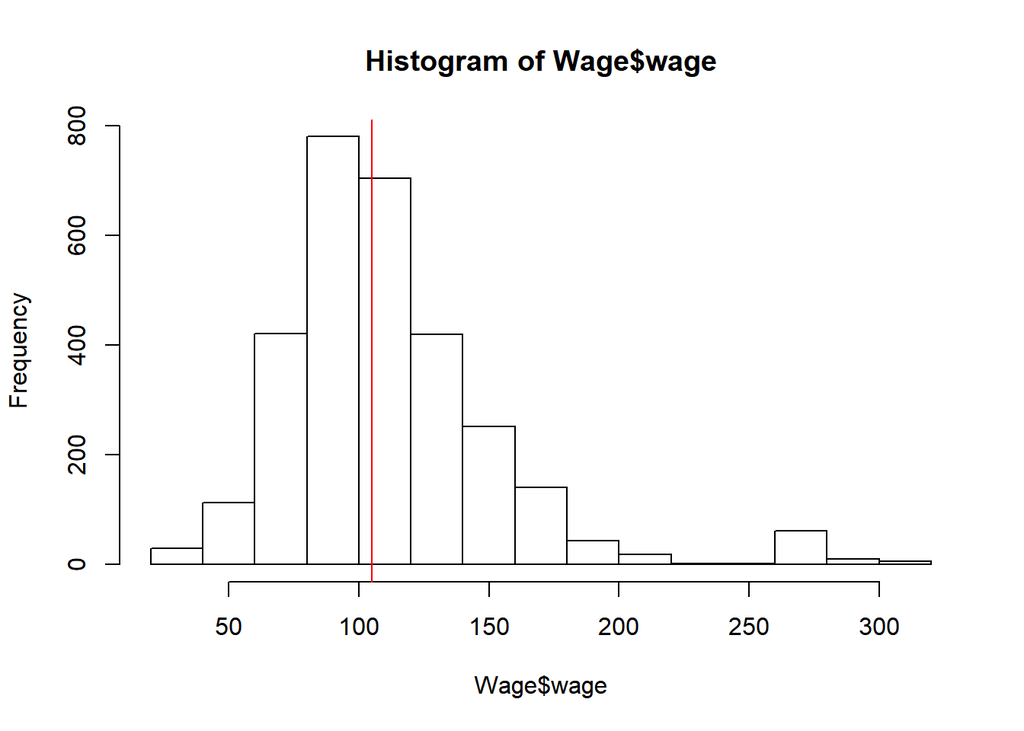

```r
hist(Wage$wage)
abline(v=median(Wage$wage),col="red")
```

Look at the plot below, you will notice that information workers are better paid for all races. There is also minor differences among the wages of different races for the same type of job.

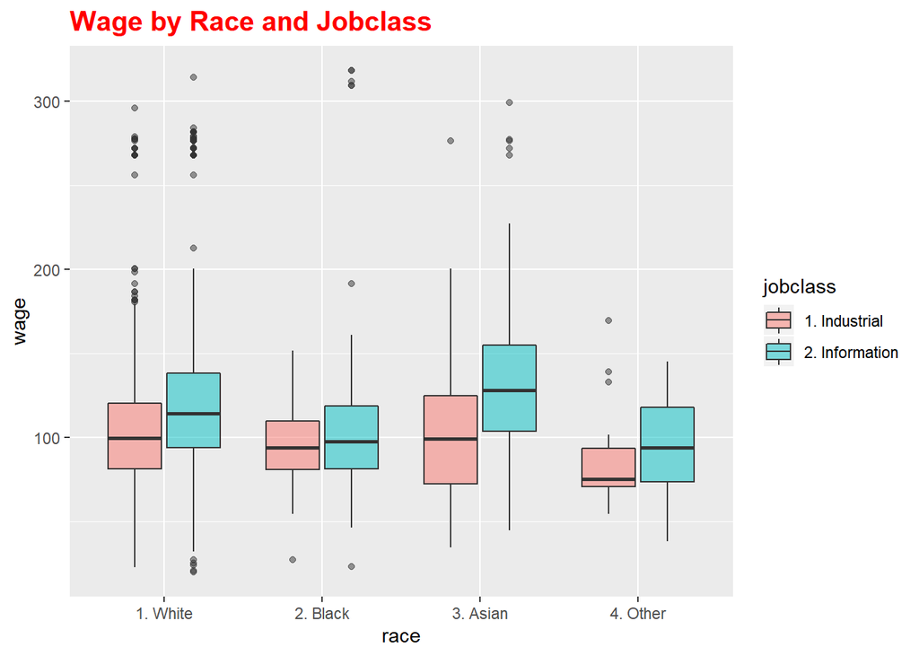

```r
ggplot(Wage, aes(x=race, y=wage, fill=jobclass)) + geom_boxplot(alpha=0.5) + ggtitle("Wage by Race and Jobclass") + theme(plot.title = element_text(color="red", face="bold", size=15))
```

Interestingly, married workers are typically paid the best. Notice that the graph only shows the correlation, so whether “success in careers will boost stability in family life” or “Happy family life will also benefits job efficiency” is still to be determined by future researches.

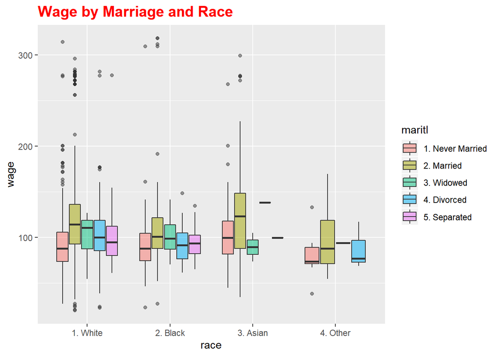

```r
ggplot(Wage, aes(x=race, y=wage, fill=maritl)) + geom_boxplot(alpha=0.5) + ggtitle("Wage by Marriage and Race") + theme(plot.title = element_text(color="red", face="bold", size=15))
```

Again, as I mentioned before it is a common sense that both higher degrees and better health will promote ones work ability therefore lead to a higher earning.

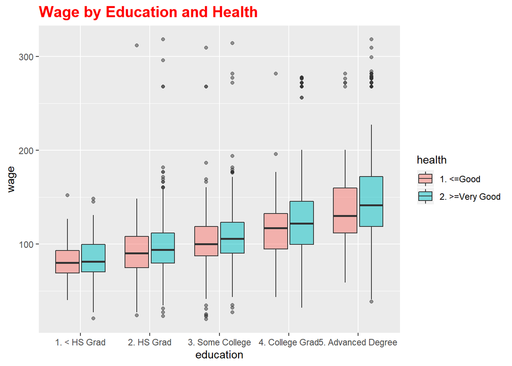

```r
ggplot(Wage, aes(x=education, y=wage, fill=health)) + geom_boxplot(alpha=0.5) + ggtitle("Wage by Education and Health") + theme(plot.title = element_text(color="red", face="bold", size=15))
```

### Model building

#### Variables selection

I am using the logwage as a response for the nature of inequality of earnings among different members in the society. That is the distribution of wages usually has a long tail in capitalism societies, i.e. there are always people like Bill Gates who have exponentially high incomes. If we do not take the log, these people can be outliers and negatively influence the prediction of our linear models. Initially, I tried to fit model directly on wages which gives me very high errors. After using the logwage, I have found the errors are generally limited to 10% of actual values which is satisfactory.

```r
# Use the regsubsets function to find the best predictors, with some obvious predictors excluded to facilitate the efficiency
library(leaps)
attach(d)
# Excluding wage because it is not a meaningful work to use wage to predict logwage
# Excluding region because all the regions are the same: "mid-Atlantic"
reg.fit = regsubsets(logwage~.-wage-region,d)
summary(reg.fit)
```

```
## Subset selection object
## Call: regsubsets.formula(logwage ~ . - wage - region, d)
## 18 Variables  (and intercept)
##                             Forced in Forced out
## year                            FALSE      FALSE
## age                             FALSE      FALSE
## maritl2. Married                FALSE      FALSE
## maritl3. Widowed                FALSE      FALSE
## maritl4. Divorced               FALSE      FALSE
## maritl5. Separated              FALSE      FALSE
## race2. Black                    FALSE      FALSE
## race3. Asian                    FALSE      FALSE
## race4. Other                    FALSE      FALSE
## education2. HS Grad             FALSE      FALSE
## education3. Some College        FALSE      FALSE
## education4. College Grad        FALSE      FALSE
## education5. Advanced Degree     FALSE      FALSE
## jobclass2. Information          FALSE      FALSE
## health2. >=Very Good            FALSE      FALSE
## health_ins2. No                 FALSE      FALSE
## edu                             FALSE      FALSE
## hea                             FALSE      FALSE
## 1 subsets of each size up to 8
## Selection Algorithm: exhaustive
##          year age maritl2. Married maritl3. Widowed maritl4. Divorced
## 1  ( 1 ) " "  " " " "              " "              " "
## 2  ( 1 ) " "  " " " "              " "              " "
## 3  ( 1 ) " "  " " "*"              " "              " "
## 4  ( 1 ) " "  "*" "*"              " "              " "
## 5  ( 1 ) " "  "*" "*"              " "              " "
## 6  ( 1 ) "*"  "*" "*"              " "              " "
## 7  ( 1 ) "*"  "*" "*"              " "              " "
## 8  ( 1 ) "*"  "*" "*"              " "              " "
##          maritl5. Separated race2. Black race3. Asian race4. Other
## 1  ( 1 ) " "                " "          " "          " "
## 2  ( 1 ) " "                " "          " "          " "
## 3  ( 1 ) " "                " "          " "          " "
## 4  ( 1 ) " "                " "          " "          " "
## 5  ( 1 ) " "                " "          " "          " "
## 6  ( 1 ) " "                " "          " "          " "
```

[output cut: 23 more lines]

```
## 3  ( 1 ) " "                    " "                  "*"             "*"
## 4  ( 1 ) " "                    " "                  "*"             "*"
## 5  ( 1 ) " "                    " "                  "*"             "*"
## 6  ( 1 ) " "                    " "                  "*"             "*"
## 7  ( 1 ) " "                    " "                  "*"             "*"
## 8  ( 1 ) " "                    " "                  "*"             "*"
##          hea
## 1  ( 1 ) " "
## 2  ( 1 ) " "
## 3  ( 1 ) " "
## 4  ( 1 ) " "
## 5  ( 1 ) "*"
## 6  ( 1 ) "*"
## 7  ( 1 ) "*"
## 8  ( 1 ) "*"
```

```r
sum.best.subset = summary(reg.fit)
```

We want to use as less predictors as necessary in the model, so we plot both $R^2$ and adjusted $R^2$. The $R^2$ is a measure of how much more variation can be explained by the fitted model compared the null model which is just predicting every member by using average of the group. While adjusted $R^2$ is the $R<sup>2</sup> adjusted with the number of predictors. The $R^2$ is always going up as we add more predictors, no matter they are really effective in the model or not. But the adjusted $R^2$ will go up only when the added predictor is efficient enough in improving the prediction result.\

Looking the plots of two values, they are always going up as the number of predictors go up, indicating in this case adding more predictors are always helpful in improving the predictio results.

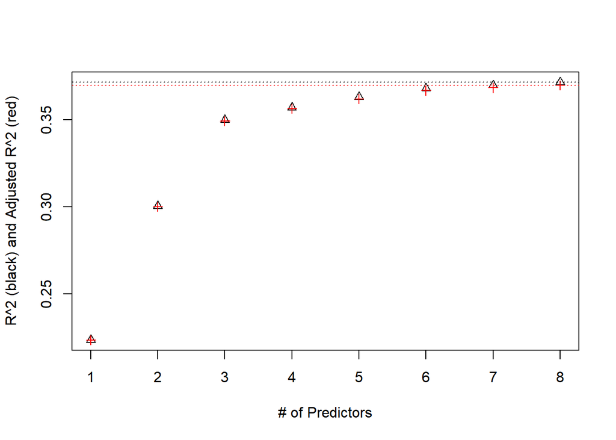

```r
plot(sum.best.subset$rsq, pch=2, xlab = "# of Predictors", ylab = "R^2 (black) and Adjusted R^2 (red)")
points(sum.best.subset$adjr2, pch=3, col="red")
abline(h=max(sum.best.subset$rsq), lty=3)
abline(h=max(sum.best.subset$adjr2), lty=3, col="red")
```

$C_p$ is an estimate of test MSE. It has a component of number of predictors. Only adding effective predictors will help reduce test errors. As you can see from the below graph, the $C_p$ is always decreaing, which again implies adding all the predictors.

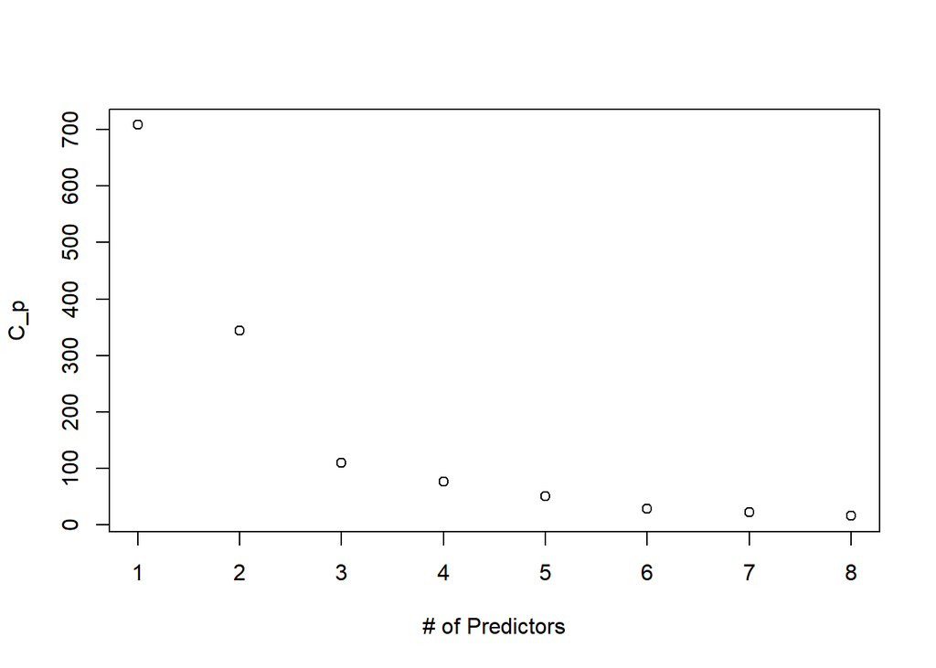

```r
plot(sum.best.subset$cp, pch=1, xlab="# of Predictors", ylab="C_p")
```

#### Fit and evaluate the Model

```r
# fit the model on all predictors
lm1 = glm(logwage~ age+edu+hea+maritl+race+jobclass)
summary(lm1)
```

```
##
## Call:
## glm(formula = logwage ~ age + edu + hea + maritl + race + jobclass)
##
## Deviance Residuals:
##      Min        1Q    Median        3Q       Max
## -1.67841  -0.15393   0.01236   0.16780   1.24565
##
## Coefficients:
##                          Estimate Std. Error t value Pr(>|t|)
## (Intercept)             3.8808491  0.0320904 120.935  < 2e-16 ***
## age                     0.0036312  0.0005306   6.843 9.36e-12 ***
## edu                     0.1199044  0.0047795  25.087  < 2e-16 ***
## hea                     0.0709641  0.0122085   5.813 6.80e-09 ***
## maritl2. Married        0.1693922  0.0147891  11.454  < 2e-16 ***
## maritl3. Widowed        0.0494572  0.0688555   0.718 0.472644
## maritl4. Divorced       0.0532650  0.0248261   2.146 0.031991 *
## maritl5. Separated      0.1270380  0.0416553   3.050 0.002310 **
## race2. Black           -0.0432132  0.0184069  -2.348 0.018957 *
## race3. Asian           -0.0298915  0.0222847  -1.341 0.179910
## race4. Other           -0.0675989  0.0486954  -1.388 0.165180
## jobclass2. Information  0.0413531  0.0113427   3.646 0.000271 ***
## ---
## Signif. codes:  0 '***' 0.001 '**' 0.01 '*' 0.05 '.' 0.1 ' ' 1
##
## (Dispersion parameter for gaussian family taken to be 0.08568687)
##
##     Null deviance: 371.07  on 2999  degrees of freedom
## Residual deviance: 256.03  on 2988  degrees of freedom
## AIC: 1156.4
##
## Number of Fisher Scoring iterations: 2
```

The residual plot is a good way to visualize the prediction errors along with prediction values. Again most of our predictions are pretty close to central line, indicating the effectiveness of our model.

```r
library(car)
```

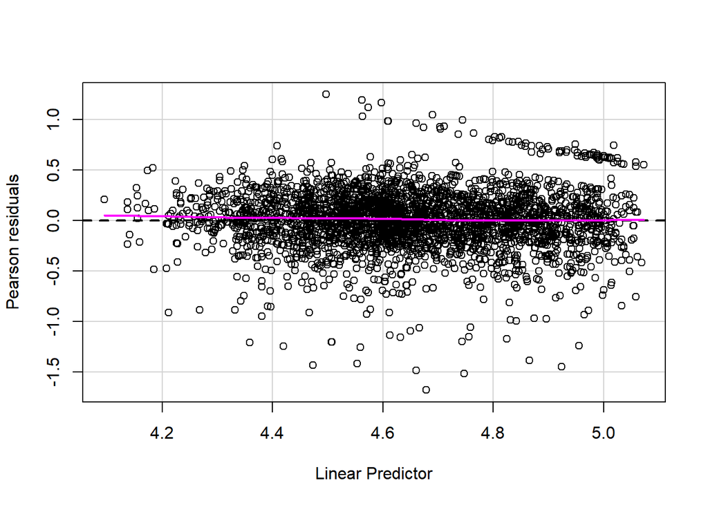

```r
residualPlot(lm1)
```

The colinearity problem means certain predictors are (nearly) linearly dependent with each other. It may cause the standard errors of the estimate increase significantly. And Variance inflation factor (VIF) is a measure of colinearity among predictors. If the VIF value is greater than 5 or 10, it typically indicates the problem of colinearity. Here all of our VIF values are smaller than 2, which is great sign that we are free of this colinearity problem.

```r
library(car)
vif(lm1)
```

```
##              GVIF Df GVIF^(1/(2*Df))
## age      1.312970  1        1.145849
## edu      1.181473  1        1.086956
## hea      1.065606  1        1.032282
## maritl   1.309946  4        1.034324
## race     1.071285  3        1.011543
## jobclass 1.125133  1        1.060723
```

The leave one out cross-validation is a method to estimate the test error. Each time the algorithm fits on all except for one of the data and test the remained one. The remained one works as the test set, which can reveal some information about our test errors. Here we have 0.085997 indicating that we should expect that the mean test error to be 0.086, which is very small compared with the range of logwage (3 - 5).

```r
# Use LOOCV to estimate the test errors
library(boot)
cv.glm(d, lm1)$delta[1]
```

```
## [1] 0.08599699
```

Similarily CV with 5-folds divides the data set into 5 subsets. Use 4 of the 5 as train set to build the model and the last subsets to estimate the test errors. Again here we have the test error estimate around 0.086.

```r
# Use cv with 5-folds to estimate the test errors
library(boot)
cv.glm(d, lm1, K=5)$delta
```

```
## [1] 0.08593856 0.08587245
```

The bootstrap is a method to estimate the variation of the coefficients of our model. It randomly samples from the original data set, fit the model and record the coefficients. This process repeat to a designated times (here is 1000 times). Then we can summarize the variation information about the coefficients, such as the standard errors.\

```r
# Use Bootstrap to estimate the uncertainty coefficients of the model
boot.fn=function (data ,index)
return(coef(glm(logwage ~ age + edu + hea + maritl + race + jobclass,data=d , subset=index)))
boot(d ,boot.fn ,1000)
```

```
##
## ORDINARY NONPARAMETRIC BOOTSTRAP
##
##
## Call:
## boot(data = d, statistic = boot.fn, R = 1000)
##
##
## Bootstrap Statistics :
##         original        bias     std. error
## t1*   3.88084913  7.392136e-05 0.0318007110
## t2*   0.00363124 -1.369164e-06 0.0005401007
## t3*   0.11990435  1.647381e-04 0.0047654628
## t4*   0.07096415 -4.112800e-04 0.0117002185
## t5*   0.16939219  2.427870e-04 0.0150062353
## t6*   0.04945720  1.982726e-04 0.0543489384
## t7*   0.05326504 -3.501112e-04 0.0248607078
## t8*   0.12703799  1.372999e-03 0.0303844875
## t9*  -0.04321317 -6.206266e-05 0.0177148267
## t10* -0.02989145 -4.472821e-04 0.0225655177
## t11* -0.06759895  1.808518e-03 0.0500269291
## t12*  0.04135307 -1.847004e-04 0.0111089974
```

#### Ridge and Lasso regressions

The Ridge regression adds a constraint to residual sum square by using a $\lambda$ times the sum sequares of the coefficients As we can see from the below graph as $\lambda$ increases the coefficients gradually approaches to zero.

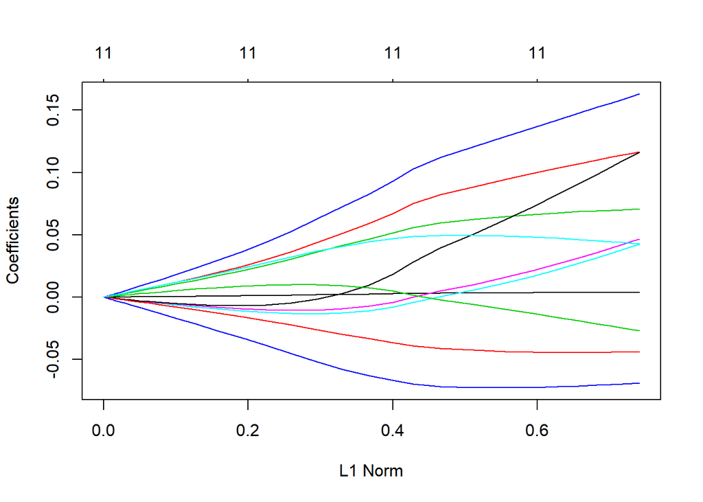

```r
x=model.matrix(logwage∼age + edu + hea + maritl + race + jobclass,d )[,-1]
y=Wage$logwage
grid=10^seq(10,-2, length =100)
ridge.mod=glmnet (x,y,alpha=0, lambda=grid)
plot(ridge.mod)
```

Here I am separating the data into test and train sets.

```r
set.seed(1)
train=sample (1: nrow(x), nrow(x)/2)
test=(-train)
y.test=y[test]
```

Here I use the train set to choose the smallest $\lambda$ 0.015525.The below graph shows the mean squared error and $log \lambda$.

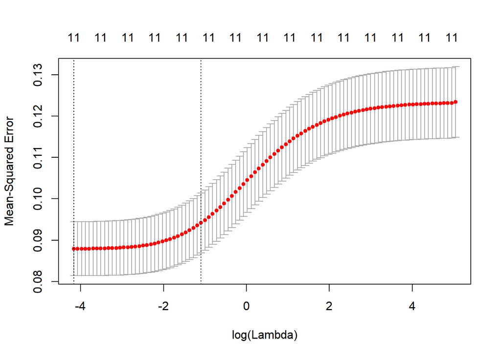

```r
set.seed(1)
cv.out=cv.glmnet(x[train ,],y[ train],alpha=0)
plot(cv.out)
```

```r
bestlam =cv.out$lambda.min
bestlam
```

```
## [1] 0.01552464
```

```r
ridge.pred=predict (ridge.mod ,s=bestlam ,newx=x[test ,])
mean((ridge.pred -y.test)^2)
```

```
## [1] 0.08358034
```

Similar with ridge, the lasso regression add a constraint to the regression by adding a $\lambda$ times the sum of the absolute values of the coefficients. But different from the ridge, the lasso will shink the coefficients to zero much faster.As we can see from the below graph, many of the coefficients (denote by lines of different colors) hits zero quickly.

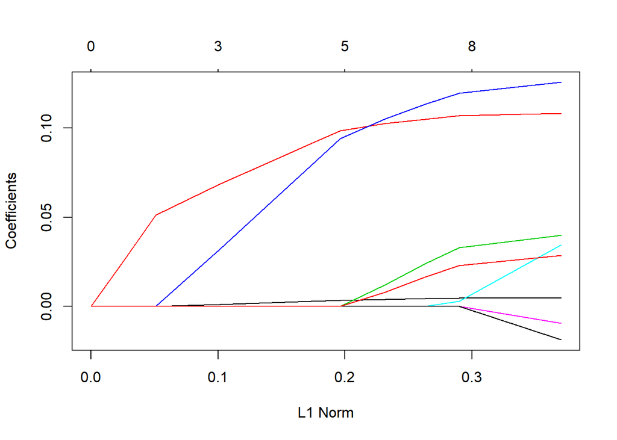

```r
lasso.mod=glmnet(x[train ,],y[ train],alpha=1, lambda =grid)
plot(lasso.mod)
```

Again similar with ridge, we find the best $\lambda$ (0.00036708) on train set and test the MSE on test set 0.085293, which is pretty small again.

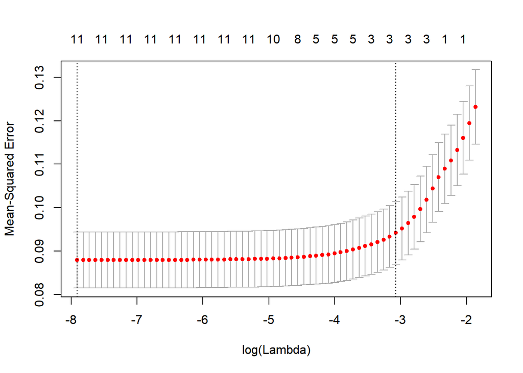

```r
set.seed(1)
cv.out=cv.glmnet(x[train ,],y[ train],alpha=1)
plot(cv.out)
```

```r
bestlam =cv.out$lambda.min
bestlam
```

```
## [1] 0.0003670785
```

```r
lasso.pred=predict (lasso.mod ,s=bestlam ,newx=x[test ,])
mean((lasso.pred -y.test)^2)
```

```
## [1] 0.08529326
```

Here we caluculate the non-zero lasso coefficients.

```r
out=glmnet (x,y,alpha=1, lambda=grid)
lasso.coef=predict(out, type="coefficients",s= bestlam) [1:8, ]
lasso.coef
```

```
##        (Intercept)                age                edu
##        3.970094159        0.003382186        0.115241987
##                hea   maritl2. Married   maritl3. Widowed
##        0.051412402        0.134973233        0.000000000
##  maritl4. Divorced maritl5. Separated
##        0.000000000        0.019129089
```

```r
lasso.coef[lasso.coef!=0]
```

```
##        (Intercept)                age                edu
##        3.970094159        0.003382186        0.115241987
##                hea   maritl2. Married maritl5. Separated
##        0.051412402        0.134973233        0.019129089
```